# Day 1 · From a table to a biological story

KN7001 Neurochemistry · statistics workshop

## Welcome · You are the data detectives

Two groups of people took a short memory test (MMSE test). Somebody claims one group scored lower. **Your mission today:** decide whether the data support that claim, make a figure that shows it, and explain the result in your own words. Along the way you will meet R, the free tool that professional biologists use for exactly this job.

You do **not** need to write code from memory. Every code window comes filled in. You run it, add a line that changes one thing, and explain what happened.

**Work in pairs.** One person drives the keyboard, the other predicts and explains. Swap roles at every new section. Quizzes are practice, not marks.

**Using an LLM (ChatGPT, Claude, Copilot, …) is allowed** for explanations, hints and debugging. Ask small questions: “explain why this command failed”, “what does this output mean”. Then check the answer yourself: do the column names it uses exist? Does it use the right group? Does its explanation agree with the R output? A confident answer can still treat repeated visits as independent people. The rule is simple: you must be able to explain everything you keep.

Every investigation today follows the same six questions:

1. What do we want to know?
2. What does one observation (one row) represent?
3. What do the data look like?
4. Which analysis answers our question?
5. What does the output mean?
6. What limits our conclusion?

### How this tutorial works

| Button | What it does |
| --- | --- |
| **Run Code** | Runs the code in the window and shows the output below it |
| **Submit Answer** | Checks whether you made the change the task asked for, and tells you what to fix if not |
| **Hints** / **Solution** | Use hints when stuck; open the solution *after* an attempt |
| **Start Over** | Resets the code window to the supplied version |
| **Continue** | Reveals the next step of the section |
| **Download my work** (in the Finish section) | Saves all your code and answers into one HTML file you can keep or hand in |

Each code window is its own tiny workspace: objects you make in one window are **not** carried into the next. We supply the data every window needs. Ordinary R scripts behave differently: later lines depend on earlier ones.

### Today’s route

Work through the missions in order, at your own pace. Each one starts with a short piece of theory you can come back to whenever an exercise feels unclear.

| Mission | Minimum outcome |
| --- | --- |
| Welcome and finding your way | Know where to type and where output appears |
| Missions 1–2: first commands, first table | Run, change, repair, import |
| Mission 3: typical values and spread | Explain mean vs median, SD, IQR, NA |
| Mission 4: make the observations visible | Read a histogram, boxplot, violin |
| Mission 5: is it normal? | Write an assumption assessment |
| Mission 6: compare the groups | A result sentence with uncertainty |
| Mission 7: many questions, many chances | Explain a Bonferroni-adjusted table |
| Mission 8: association detective | Read a scatterplot and a correlation |
| Finish: what you can do now, prepare Day 2 | Exit ticket |

There are two breaks, after Mission 3 and after Mission 5. Sections after the Finish (**Toolbox**, **Gallery**, **Extras**) are optional reference material for curious pairs and for Day 2.

### Where do I type?

The most common question of the day. Here is the map.

| Place | What you do there | What is saved? |
| --- | --- | --- |
| A code window in this tutorial | Edit supplied R, click **Run Code** | Your last attempt, in this browser |
| A text box in this tutorial | Write an explanation, click **Record** | Your last answer, in this browser |
| RStudio **Console** (the `>` prompt) | Try a quick command | Nothing. It is gone when R restarts |
| An R script or R Markdown file in the RStudio **editor** | Write commands you want to keep | The file, when you save it. Tomorrow’s tool |

Your attempts are remembered by this browser on this computer, and at the end you can **download everything you typed** as one HTML file (Finish section).

## Mission 1 · Make R do something

**Goal:** run, change, break, repair.

### The ideas behind this mission

R is a programming language for data: you write an instruction, R carries it out and shows the result. Think of it as a lab protocol that a very literal assistant follows. The assistant never improvises, so every step has to be spelled out, and every step can be repeated exactly. That is the whole point. When you analyse data by clicking in a spreadsheet, nobody (not even you, a month later) can say exactly what was done. A script written in R is the protocol itself: run it again and you get the same result, hand it to a colleague and they can check every step. Journals and reviewers increasingly ask for exactly this.

Three words cover most of what you will see today. An **object** is anything R has stored under a name: a single number, a list of measurements, a whole table. A **function** is a verb: `mean()`, `plot()`, `read.csv()`. You give it an input inside the round brackets and it returns a result. An **argument** is an extra setting you pass to a function, written as `name = value`, such as `digits = 2`. Almost every line of R is “take this object, apply this function with these arguments”.

Errors are part of the workflow, not a sign that you are bad at this. R stops at the first thing it does not understand and prints a message in red. The useful information is almost always in the *last* line of that message: which name was not found, which bracket was missing. Experienced users see errors every day; the difference is that they read the message instead of panicking. RStudio is the desk you sit at while doing all this. In this tutorial, click **Run Code** under each window.

### R is a calculator

**Predict → run → change.** What will this print? Run it, then add a second line `2 + 10` and click **Submit Answer**.

```
2 + 4
```

```
# Keep the first line. On a new line below it, type 2 + 10, then click Run Code again.
```

```
2 + 4
2 + 10
```

Try a few more. R has hundreds of built-in functions; a function is a verb with round brackets. Run these, then add a line that computes the square root of 144 and **Submit Answer**.

```
10 / 3
2^10
sqrt(81)
```

```
# sqrt() is the square-root function. Put the number inside the brackets.
```

```
10 / 3
2^10
sqrt(81)
sqrt(144)
```

### Remember things with a name

`<-` means “store the value on the right under the name on the left”. `c()` **combines** values into a **vector** (a list of values of the same kind). A function such as `mean()` takes an input and returns a result.

Run these lines. Then add a line that calculates the median of the scores. Finally, ask R what `scores` contains by writing `scores` alone on a new line, and **Submit Answer**.

```
scores <- c(27, 28, 30, 27, 29)
mean(scores)
```

```
# Keep the first two lines. On a third line add median(scores).
```

```
# A name alone on a line prints the object:
# scores
```

```
scores <- c(27, 28, 30, 27, 29)
mean(scores)
median(scores)
scores
```

Rules that prevent most beginner errors:

- Text needs quotation marks: `"AD"`. Names of objects do not: `scores`.
- R distinguishes capitals: `Scores` and `scores` are different objects.

Now make your own vector called `my_scores` with five numbers of your choice and compute its mean. Click **Submit Answer** when your last line is the mean.

```
my_scores <- c(10, 20, 30, 40, 50)   # replace these with five numbers of your own
mean(my_scores)
```

```
# Put five numbers separated by commas inside c( ). Example: c(21, 25, 30, 18, 27)
```

```
my_scores <- c(21, 25, 30, 18, 27)
mean(my_scores)
```

**Quiz:** After running scores <- c(27, 28, 30), what does R print?

- The three numbers
- Nothing: assignment stores the values silently
- An error, because scores did not exist before

**Discuss with your partner, then reveal**

Nothing: assignment stores the values silently. Assignment is silent. Type the name alone to see what is stored.

### Break it on purpose

Errors are information, not punishment. This window contains a deliberate misspelling. Run it, read the **last line** of the red message, then repair the name and **Submit Answer**.

```
scores <- c(27, 28, 30)
# The next line has a typo. Read the error, then fix it.
mean(score)
```

```
# The object is called scores (with an s). R never guesses; it needs the exact name.
```

```
scores <- c(27, 28, 30)
mean(scores)
```

**Quiz:** R says: Error: object ‘score’ not found. What is the most likely cause?

- R is broken and must be reinstalled
- The name is misspelled, or the line that creates the object was never run
- The data file is corrupt

**Discuss with your partner, then reveal**

The name is misspelled, or the line that creates the object was never run. Object not found is the most common error of the day. Check spelling, then re-run the line that creates the object.

## Mission 2 · Open the evidence

**Goal:** import a table, look inside it, and say what one row means.

### The ideas behind this mission

Almost every dataset in biology can be written as a rectangular table: one **row per observation** and one **column per variable**. A plate reader export has one row per well; a patient registry has one row per patient (or per visit); a microscopy summary has one row per cell. R calls such a table a **data frame**. Getting the data into this shape, and knowing what a row is, is half the analysis. The other half is the statistics, and it depends on the first half more than most people realise.

Ask, for every table you meet: **what does one row represent?** This is the **observation unit**. It decides how many independent pieces of evidence you really have. Twenty rows can be twenty people, or two people measured ten times each, and every test you run later assumes you know which. No amount of R can recover that information from the numbers alone; it comes from how the data were collected.

Columns come in kinds. Some hold measurements with meaningful distances (**continuous**: age, volume, concentration). Some hold ordered categories where the spacing between levels is not fixed (**ordinal**: mild < moderate < severe). Some hold plain labels with no order (**nominal**: sex, treatment, cell type). R stores whatever the file says, usually numbers or text, and cannot tell a severity score from a temperature. You have to, because the kind of variable decides which summaries and tests make sense.

### The case file: a small MMSE table

The **MMSE** (Mini-Mental State Examination) is a 30-point questionnaire used in clinics to screen for cognitive impairment: orientation, recall, attention, language and copying a simple drawing. Scores are whole numbers from 0 to 30 and higher is better. Roughly, 24–30 is the usual range for unimpaired adults, and lower scores indicate more impairment — but a score alone is not a diagnosis.

`data/mmse_small.csv` holds **20 rows and 3 columns**:

| Column | Type | What it holds |
| --- | --- | --- |
| `id` | text | A label for the row (`Control_01`, `AD_03`, …). It is an identifier, not a measurement |
| `group` | text | `Control` or `AD` (Alzheimer’s disease), 10 rows each |
| `MMSE` | number | The test score, 0–30 |

**One row is one person, tested once.** Each row is an independent measurement: no one appears twice, and no score depends on any other score. That is the single most important fact about this table, because every test you run today assumes it.

`read.csv()` reads a comma-separated file into a **data frame**: a table where each column is a variable and each row is an observation. The path `data/mmse_small.csv` starts inside this project folder.

Run the import and the four inspection commands. Match each output to the table you can imagine: how many rows, how many columns, which types? Then add `summary(mmse)` as a fifth command and **Submit Answer**.

```
mmse <- read.csv("data/mmse_small.csv")
head(mmse)
dim(mmse)
names(mmse)
str(mmse)
```

```
# head() shows the first 6 rows; dim() gives rows and columns; names() the column
# names; str() the structure (type of each column). Try summary(mmse) too.
```

```
mmse <- read.csv("data/mmse_small.csv")
head(mmse)
dim(mmse)
names(mmse)
str(mmse)
summary(mmse)
```

**Quiz:** dim(mmse) printed 20 3. What does it mean?

- 20 columns and 3 rows
- 20 rows (observations) and 3 columns (variables)
- 20 people were tested 3 times

**Discuss with your partner, then reveal**

20 rows (observations) and 3 columns (variables). R always reports rows first, then columns.

### Nested functions: order matters

R reads nested instructions **from the inside out**: the innermost result becomes the input to the function around it. Everything today is built from this one habit, so it is worth doing slowly once.

Below are the same two functions, `sqrt()` and `sum()`, nested in the two possible orders. Predict both answers, then run it. Do they agree?

```
sqrt(sum(c(9, 16)))    # square-root of the sum
sum(sqrt(c(9, 16)))    # sum of the square-roots
```

```
# Inside out: the first line adds 9 + 16 = 25, then takes the root.
# The second takes roots first (3 and 4), then adds them.
```

```
sqrt(sum(c(9, 16)))
sum(sqrt(c(9, 16)))
```

**Quiz:** Why do sqrt(sum(c(9, 16))) and sum(sqrt(c(9, 16))) give 5 and 7?

- R evaluates left to right, so the first function wins
- R evaluates the innermost call first, so the two lines do the operations in opposite order
- One of them is a mistake

**Discuss with your partner, then reveal**

R evaluates the innermost call first, so the two lines do the operations in opposite order. Inside out, every time. The brackets, not the reading order of the words, decide what happens first.

### One column at a time

`$` picks one column out of a data frame and gives you a vector. Run this, then add an additional line with `summary` of the MMSE column. Finally use a nested function, apply `table` on the `group` column. Submit when the window ends with the group counts.

```
range(mmse$MMSE)
```

```
# The column is called MMSE, in capitals. summary() gives min, quartiles, mean, max.
```

```
# table(mmse$group) counts how many rows belong to each group.
```

```
summary(mmse$MMSE)
table(mmse$group)
```

To keep one group only, ask R for the rows where `group` equals `"AD"`. Note the double `==` (a question: “is it equal?”) versus the single `=` (usually used for a function argument). Run it, then add the same three lines for the control group, stored as `control`, and **Submit Answer**.

```
ad <- mmse$MMSE[mmse$group == "AD"]
ad
length(ad)
```

```
# Copy the pattern for the other group: control <- mmse$MMSE[mmse$group == "Control"]
```

```
ad <- mmse$MMSE[mmse$group == "AD"]
control <- mmse$MMSE[mmse$group == "Control"]
ad
control
length(ad)
length(control)
```

From here on, the vectors `ad` and `control` (and the data frame `mmse`) are already prepared in every code window, so you do not need to repeat the import.

### What is a row, and what kind of variable is that?

**Quiz:** What does one row of mmse represent in our dataset?

- A group average
- One person, with a group label and a score
- One question of the MMSE questionnaire

**Discuss with your partner, then reveal**

One person, with a group label and a score. The observation unit decides everything that follows: how many independent observations we have and which tests are fair.

**Quiz (choose all that apply):** Which statements about variable types are correct? (choose all that apply)

- group (Control/AD) is a nominal variable: categories with no order
- A dementia severity rating coded 0, 0.5, 1, 2 is ordinal: ordered categories
- Age in years is a continuous (numeric) variable
- An MMSE score of 20 means twice the cognitive ability of a score of 10

**Discuss with your partner, then reveal**

group (Control/AD) is a nominal variable: categories with no order; A dementia severity rating coded 0, 0.5, 1, 2 is ordinal: ordered categories; Age in years is a continuous (numeric) variable. Storage as a number does not define the measurement scale. MMSE is a bounded score: differences in points are meaningful, ratios are not.

**🔍 Deeper: continuous, ordinal, nominal**

- **Continuous / numeric:** measurements with meaningful distances (height, blood volume, brain volume). Summarise with mean and SD, or median and IQR.
- **Ordinal:** ordered categories (mild < moderate < severe; socioeconomic status 1–5). Order matters, spacing does not. Prefer medians, counts and rank methods.
- **Nominal:** unordered labels (cell type, sex, treatment group). Count them.

R stores ordinal codes as numbers if the file does. `str()` shows the storage type; only you know the scientific meaning.

## Mission 3 · What is typical, and how variable?

**Goal:** explain mean versus median, SD versus uncertainty, and the IQR.

### The ideas behind this mission

Suppose you measured neurite length in twenty cultures. Nobody wants to read twenty numbers, so you summarise: a **typical value** (the centre) and a **measure of how much the cultures differ** (the spread). These are **descriptive statistics**. They describe the sample you have in hand. Every summary throws information away on purpose, and the skill is to choose a summary that keeps what matters for your question.

There are two families. The **mean** and **standard deviation (SD)** use every value and its exact size, which makes them efficient when the data are roughly symmetric but easily dragged around by one extreme value (a contaminated well, a mislabelled patient). The **median** and **quartiles** use only the order of the values, so a wild value moves them very little. When a distribution is skewed or has outliers, the median tells you more honestly where the typical observation sits. Reporting both, and looking at the raw points, is never wrong.

### Centre and spread in one breath

- **Mean:** add everything up, divide by the count. Sensitive to extreme values.
- **Median:** sort the values, take the middle one. Ignores how extreme the extremes are.
- **SD (standard deviation):** typical distance of an observation from the mean, in the same units as the data. For a bell-shaped distribution about 68% of values lie within one SD of the mean and 95% within two.
- **Quartiles:** the values that cut the sorted data into quarters. **IQR = Q3 − Q1** is the width of the middle half.

Every summary throws information away. The art is choosing which to keep.

### The outlier detective

Four measurements: 23.2, 14.8, 31.7 and 19.3. The fifth is yours to move. **Predict first:** as you drag it upwards, which line follows it, and which stays put?

Two positions worth visiting. At **100** the mean climbs to 37.8 while the median sits at 23.2: the red line is above every one of the four original measurements. At **0** the mean falls to 17.8 and the median only to 19.3.

Across the whole slider, from 0 to 100, the median travels about four points. The mean travels twenty. One measurement out of five cannot drag the median anywhere, because the median only cares about the *order* of the values, not how extreme the extremes are.

**Number check:** Drag the point somewhere above 25 until the red and blue lines lie exactly on top of each other. What is the fifth measurement there?

**Discuss with your partner, then reveal**

27. At 27 the values are balanced around 23.2, so mean and median agree there. Roughly symmetric data are the case where the choice of centre does not matter; the further you drag from 27, the more it matters.

**Quiz:** One extreme value dragged the mean from 23.2 to 37.8 while the median stayed at 23.2. A real dataset has such a value. What do you do?

- Delete it until the result looks nice
- Check the measurement and its context; document any exclusion and the reason
- Replace it with the median so nobody notices

**Discuss with your partner, then reveal**

Check the measurement and its context; document any exclusion and the reason. An unusual value can be real biology or a pipetting error. Appearance alone is never a reason to delete data.

### Quartiles and the IQR

Run the supplied summaries of the control group. Then answer the number question below.

```
mean(control)
median(control)
sd(control)
quantile(control, probs = c(0.25, 0.5, 0.75))
IQR(control)
```

```
# The 25% value is Q1 and the 75% value is Q3. IQR() subtracts them for you.
```

```
quartiles <- quantile(control, probs = c(0.25, 0.75))
quartiles[2] - quartiles[1]
IQR(control)
```

**Number check:** What is the IQR of the control MMSE scores (in points)?

**Discuss with your partner, then reveal**

1.75. Q3 = 28.75 and Q1 = 27, so the middle half of controls spans 1.75 points. The controls are tightly packed near the top of the scale.

Now the same summaries for both groups at once. `tapply()` applies a function to each group separately: read it as “apply `mean` to `MMSE` split by `group`”. Add a second line with `sd` instead of `mean`, then a third with `median`, and **Submit Answer**.

```
tapply(mmse$MMSE, mmse$group, mean)
```

```
# tapply(mmse$MMSE, mmse$group, sd)
```

```
tapply(mmse$MMSE, mmse$group, mean)
tapply(mmse$MMSE, mmse$group, sd)
tapply(mmse$MMSE, mmse$group, median)
```

### Missing values are unknown, not zero

R writes a missing value as `NA`. This separate demonstration vector has one. Run it: the mean is `NA` because R refuses to guess. Then add a new line `mean(signal_missing, na.rm = TRUE)` and **Submit Answer**. How many measurements contributed?

```
signal_missing <- c(8, 9, NA, 11, 12)
mean(signal_missing)
sum(is.na(signal_missing))
sum(!is.na(signal_missing))
```

```
# mean(signal_missing, na.rm = TRUE)   -- na.rm means "remove NA before computing"
# is.na() asks "is this missing?"; ! means "not".
```

```
signal_missing <- c(8, 9, NA, 11, 12)
mean(signal_missing)
mean(signal_missing, na.rm = TRUE)
sum(is.na(signal_missing))
sum(!is.na(signal_missing))
```

**Quiz:** What does na.rm = TRUE do?

- It recovers the missing measurement
- It leaves the missing value out of this calculation; we still report how many were missing
- It replaces NA with zero

**Discuss with your partner, then reveal**

It leaves the missing value out of this calculation; we still report how many were missing. Four values contributed. Why a value is missing may itself matter (a broken well, a patient who left).

**Break.** Your brain is part of the analysis pipeline.

## Mission 4 · Let the observations speak

**Goal:** read a histogram, a boxplot with points and a violin; know what a bar chart hides.

### The ideas behind this mission

Plot before you test. A table of summaries can look identical for datasets that are completely different: the same mean and SD can come from a neat bell shape, from two separate clusters, or from nineteen similar values and one extreme one. A picture of the individual observations shows the **shape** of a distribution, and that shape decides which summaries and which tests are sensible. Skipping the plot is how most wrong analyses start.

Shape has a small vocabulary worth learning. A **symmetric** distribution has a mirror-image left and right; the mean and median agree. A **skewed** one has a long tail on one side (reaction times, cell counts, concentrations often tail to the right), and the tail pulls the mean away from the median. A **bimodal** distribution has two humps, which usually means two kinds of thing were mixed together. A **ceiling** or **floor** effect appears when a measurement cannot go above or below a limit, so values pile up at that limit; a 30-point test score is a classic case. Ties (many identical values) and outliers (values far from the rest) are also part of the description.

Different plots show different things. A **histogram** shows the shape of one variable but depends on how wide you make the bins. A **boxplot** compresses a distribution into five numbers (median, quartiles, whiskers) and is good for comparing groups side by side, but it hides sample size and any structure inside the box. A **strip chart** draws every observation, which is why today we put the points on top of every box. A **bar chart of means** shows one number per group and nothing else; it is the most common plot in biology papers and the least informative.

Our question: **How do the MMSE distributions differ between the two groups?**

### Histogram: the shape of a distribution

A histogram cuts the axis into bins and counts observations in each. The picture depends on the bins. Run the two histograms (same bins, same axes). Then copy the two `hist()` commands below them and in the copies use `by = 5`, so you get a second pair of panels. **Submit Answer**. Did the observations change? Did the picture?

```
par(mfrow = c(1, 2))   # two plots side by side
hist(control, breaks = seq(0, 30, by = 3), xlim = c(0, 30), ylim = c(0, 10),
     main = "Control", xlab = "MMSE (points)", col = "#9bd5db")
hist(ad, breaks = seq(0, 30, by = 3), xlim = c(0, 30), ylim = c(0, 10),
     main = "AD", xlab = "MMSE (points)", col = "#f4bb8b")
```

```
# Keep identical breaks and axis limits for both groups so they are comparable.
# The copies differ from the originals only in by = 5.
```

```
par(mfrow = c(1, 2))
hist(control, breaks = seq(0, 30, by = 3), xlim = c(0, 30), ylim = c(0, 10),
     main = "Control", xlab = "MMSE (points)", col = "#9bd5db")
hist(ad, breaks = seq(0, 30, by = 3), xlim = c(0, 30), ylim = c(0, 10),
     main = "AD", xlab = "MMSE (points)", col = "#f4bb8b")
hist(control, breaks = seq(0, 30, by = 5), xlim = c(0, 30), ylim = c(0, 10),
     main = "Control", xlab = "MMSE (points)", col = "#9bd5db")
hist(ad, breaks = seq(0, 30, by = 5), xlim = c(0, 30), ylim = c(0, 10),
     main = "AD", xlab = "MMSE (points)", col = "#f4bb8b")
```

**Quiz:** Changing the bin width changed the histogram’s shape. What does that teach us?

- One of the two histograms is wrong
- A histogram is a summary that depends on a choice; try more than one bin width before describing shape
- Histograms are useless for small samples

**Discuss with your partner, then reveal**

A histogram is a summary that depends on a choice; try more than one bin width before describing shape. With ten values per group, every histogram is rough. Describe centre, spread, skew and the ceiling near 30; do not read a bell shape as proof of normality.

### Boxplot with every point on top

`MMSE ~ group` reads as “MMSE by group”. The **jitter** spreads points sideways so tied scores do not hide each other; it does not change any value. Run the plot and describe the group difference *and* the variation inside each group.

```
boxplot(MMSE ~ group, data = mmse, ylim = c(0, 30),
        xlab = "group", ylab = "MMSE (points)", col = c("#9bd5db", "#f4bb8b"))
set.seed(1)
stripchart(MMSE ~ group, data = mmse, vertical = TRUE,
           method = "jitter", add = TRUE, pch = 16)
```

```
# Try removing the stripchart lines: what do you lose? Then put them back.
```

```
boxplot(MMSE ~ group, data = mmse, ylim = c(0, 30),
        xlab = "group", ylab = "MMSE (points)", col = c("#9bd5db", "#f4bb8b"))
set.seed(1)
stripchart(MMSE ~ group, data = mmse, vertical = TRUE,
           method = "jitter", add = TRUE, pch = 16)
```

Anatomy of a boxplot: the thick line is the **median**; the box spans the **quartiles** (the middle half, height ≈ IQR); whiskers reach the most extreme observations within 1.5 × IQR of the box; anything beyond is drawn as a separate point. Such points are “unusual”, not automatically “wrong”.

**Quiz:** The box in a boxplot shows…

- A 95% confidence interval for the mean
- The middle half of the observations, from the first to the third quartile
- The minimum and maximum of the data

**Discuss with your partner, then reveal**

The middle half of the observations, from the first to the third quartile. The box is a picture of Q1, median and Q3 from Mission 3. It describes the data, not the uncertainty of an estimate.

### What disappeared? Bars versus points

Many papers show a bar for each group mean. Compare this bar chart with the boxplot above. What do you no longer know?

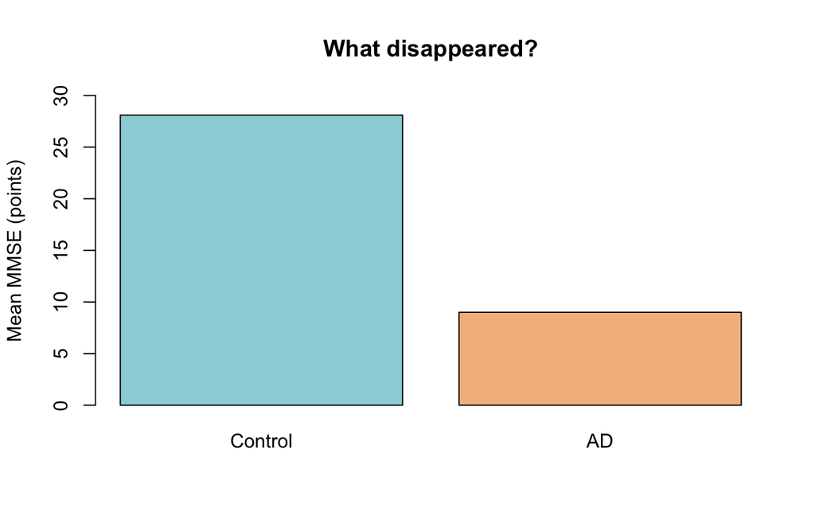

**Quiz:** What does a mean-only bar chart hide that the point plot reveals?

- The individual values, the sample size, ties and the spread within each group
- The names of the groups
- Nothing important

**Discuss with your partner, then reveal**

The individual values, the sample size, ties and the spread within each group. Two bars can look identical for n = 3 and n = 300, or for tight and wildly scattered data. Show the points whenever you can.

### Violin plot

A **violin plot** draws an estimated density: wider where more observations are believed to be. It is a smooth guess, not the data. With ten integer scores per group the smooth outline suggests more detail than exists, which is why the dots stay on top. You do not need to learn the `ggplot2` code today; the Gallery section explains it if you are curious.

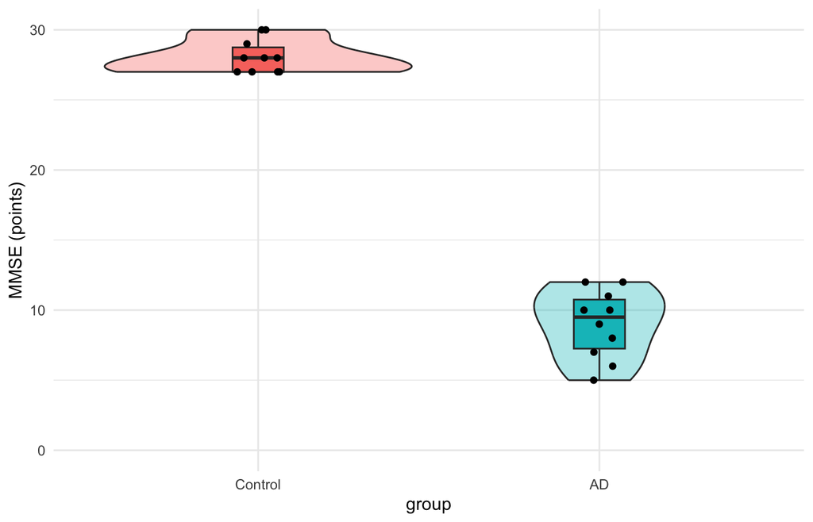

**Quiz:** What does the width of a violin represent?

- The number of people, exactly
- An estimated density: where values are more common, smoothed by a formula
- The 95% confidence interval

**Discuss with your partner, then reveal**

An estimated density: where values are more common, smoothed by a formula. Violins are useful with many observations. With n = 10 the smoothing invents shape; keep the points visible.

**Quiz:** Which plot answers: ‘Do individual AD scores overlap with individual control scores?’

- A bar chart of the two means
- A boxplot or strip chart showing every observation
- A pie chart

**Discuss with your partner, then reveal**

A boxplot or strip chart showing every observation. Questions about individuals need a plot that shows individuals.

**Your explanation:** Write a two-sentence figure caption for the boxplot: one observed pattern and one limitation.

**Discuss with your partner, then reveal**

Example: ‘Boxplot of MMSE scores for the Control and AD groups. AD scores (median 9.5) were lower than controls (median 28) with no overlap between groups; scores were more variable within the AD group. Ten people per group of undocumented origin limit any generalisation.’

## Mission 5 · Is it normal? Assumptions are evidence, not a traffic light

**Goal:** inspect each group, interpret Shapiro–Wilk with care, and write an assumption assessment *before* seeing any group-test p-value.

### The ideas behind this mission

Every statistical test is built on a **model**: a simplified story about how the data came to be. A t-test’s story is “each group’s values scatter around its own mean in a roughly bell-shaped way, and every observation is independent of every other”. The p-values and confidence intervals a test prints are only as trustworthy as that story. This is exactly like a calibration curve: the concentrations you read off it are only right if the assay really is linear over that range. Checking assumptions is checking whether the story is close enough to reality for the numbers to mean what they claim.

The assumption that matters most is **independence**: that each observation carries its own new piece of information. Ten cells from one dish, or three visits of the same patient, are not independent, and no test can detect this from the numbers. It comes from the design, so you have to know what one row is (Mission 2). The **normality** assumption is about the shape of values within each group, and it matters less than students fear: with reasonably sized, roughly symmetric samples the t-test is robust, meaning it still gives sensible answers when the shape is not perfectly bell-shaped. It matters more with small, skewed samples or heavy outliers.

You will see two ways to look at shape. Plots (histogram, **Q–Q plot**) show you *how* the data depart from normal: skew, ceiling, ties, one stray value. A **normality test** such as Shapiro–Wilk gives a single p-value that says how surprising the sample shape would be if the population were normal. Small samples rarely produce a small p-value even when the shape is odd; huge samples produce small p-values for trivial departures. Treat the test as one piece of evidence next to the plots, never as a traffic light that decides the test for you. The decision is yours, and it should be written down before you see any result.

### First the question, then the shape

Before asking “is it normal?”, important things to know:

**1. What is the question:** Do AD and Control differ in mean MMSE, and by how many points?

**2. What is independent?** Mission 2 told us: one row is one person, tested once, ten per group, nobody appearing twice. Every test in this mission assumes this, and **none of them can check it**. Independence is a fact about how the data were collected, and it is invisible in the actual test.

**3. What scale is the measurement?** MMSE is a bounded score: whole numbers from 0 to 30, nothing in between, and our controls are packed into 27–30 against the ceiling. A normal distribution is continuous and unbounded. Our control scores cannot be exactly normal, and with that pile-up at the ceiling they are not even approximately normal. You can predict what a normality test will say about them without running it.

By the time you look at the histogram and Q–Q plot, you already know what you expect to see, so the plot confirms or surprises you instead of deciding for you.

**Parametric** tests (t-test, ANOVA) describe each group with parameters — a mean and an SD — and return an estimate in the original units: “AD scored 19 points lower, 95% CI 17 to 21 points”. They assume roughly bell-shaped values within each group and tolerate moderate departures without much damage.

**Non-parametric** tests (Wilcoxon, Kruskal–Wallis) discard the values and keep only their order. No bell shape needed, and extreme values lose their leverage. The price is what you get back: you learn that one group tends to rank higher, not by how many MMSE points.

### The normal distribution

The **normal (Gaussian) distribution** is the symmetric bell curve described by two numbers, the mean and the SD. Many biological measurements are approximately normal because they are the sum of many small independent influences (genes, diet, measurement noise). The SD is the natural ruler of a bell curve: about **68%** of values lie within 1 SD of the mean, **95%** within 2 SD and **99.7%** within 3 SD. The histogram below shows 10 000 simulated values with mean 50 and SD 10, with those boundaries drawn on top, and the percentages actually observed in the simulation.

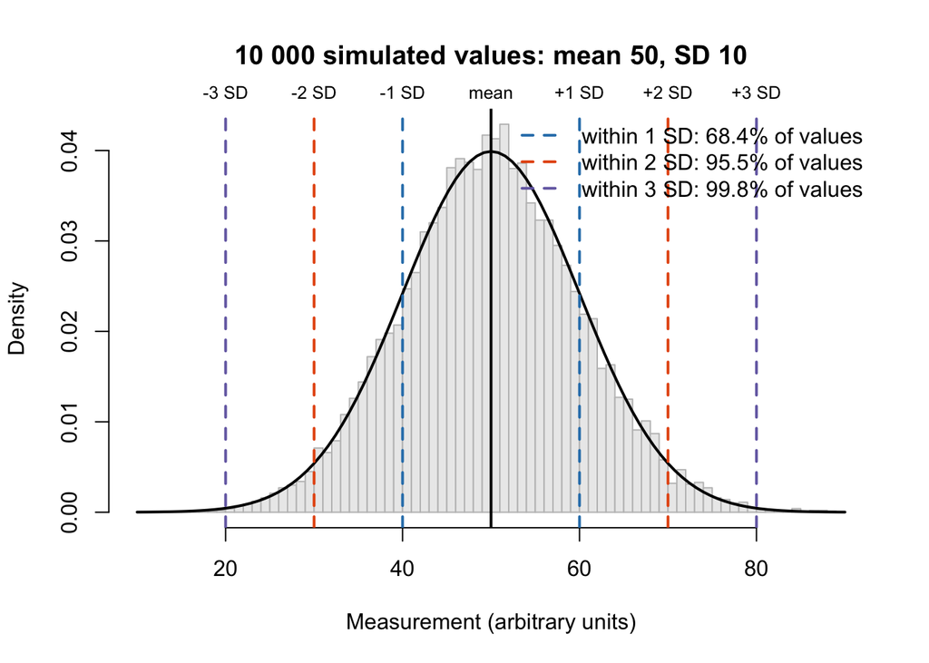

Read the picture from the middle outwards: one SD either side of the mean already covers two thirds of all values, two SD nearly everything, and a value beyond 3 SD is a one-in-three-hundred event. This is why “how many SDs away” is a useful description of how unusual a value is, and why a value 4 SD from the mean of a bell-shaped sample deserves a second look at the pipette.

Real data depart from the bell in recognisable ways. Skewed distributions (a long tail on one side) pull the mean away from the median. Bounded scores such as MMSE pile up at the ceiling. An exactly normal variable is continuous and unbounded, so for MMSE normality is at best an approximation, and for the controls not even that.

### The Q–Q plot

A **Q–Q plot** sorts your values and plots them against the values a perfect normal distribution would produce. Points near the line support the approximation; curves, steps and stray ends deserve attention. Inspect each group separately.

```
par(mfrow = c(1, 2))
qqnorm(control, main = "Control MMSE"); qqline(control)
qqnorm(ad, main = "AD MMSE"); qqline(ad)
```

```
# Look for horizontal steps (repeated integer scores) and the flat top of the
# control group near 30. The plot cannot tell you whether people are independent.
```

```
par(mfrow = c(1, 2))
qqnorm(control, main = "Control MMSE"); qqline(control)
qqnorm(ad, main = "AD MMSE"); qqline(ad)
```

### The Shapiro–Wilk test

Shapiro–Wilk asks: “If the population were normal, how surprising would this sample shape be?” Its null hypothesis is normality. A small p-value is evidence *against* normality. A large p-value is **not** proof of normality; with ten values the test has little power.

Run both. Complete the sentence: “For the ___ group the test detected / did not detect evidence against normality (p = *); this does not prove* .”

```
shapiro.test(control)
shapiro.test(ad)
```

```
# The controls pile up at 27-30 (ceiling effect) and contain many ties.
# That is why their p-value is smaller, even though nothing is "wrong" with them.
```

```
shapiro.test(control)
shapiro.test(ad)
```

**Quiz:** Shapiro–Wilk gives p = 0.58 for the AD group. Which claim is justified?

- The AD scores are proven to be normally distributed
- No evidence against normality was found; with n = 10 this is weak information either way
- There is a 58% chance the population is normal

**Discuss with your partner, then reveal**

No evidence against normality was found; with n = 10 this is weak information either way. Failure to reject is not proof. With large samples the same test flags tiny, harmless deviations.

**Quiz:** The control group gives p ≈ 0.03. What is the most useful reading?

- The control data are wrong and must be deleted
- The scores are squeezed against the 30-point ceiling with many ties, so a normal model fits them poorly; consider this when choosing and interpreting a test
- The t-test is now forbidden by law

**Discuss with your partner, then reveal**

The scores are squeezed against the 30-point ceiling with many ties, so a normal model fits them poorly; consider this when choosing and interpreting a test. The test is doing its job: flagging a bounded, tied sample. What to do about it is a scientific decision, not an automatic rule.

**Quiz:** You measure ten cells from each of three culture dishes. How many independent observations do you have for a between-dish treatment effect?

- 30
- 3
- Whatever the Shapiro test says

**Discuss with your partner, then reveal**

3. Cells within a dish share conditions. More rows are not more independent replicates. No normality test can detect this.

### Why not pool everything first?

Mixing two groups with different centres produces a shape unlike either group. The pooled histogram below is *bimodal*: two humps. Pooling is fine for some descriptive questions, but the assumption check for a two-group comparison is **within each group**.

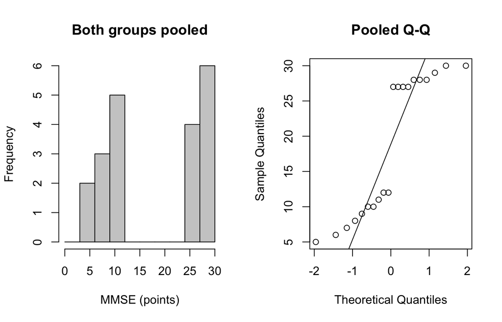

Run Shapiro–Wilk on the pooled scores and compare with the within-group results.

```
shapiro.test(mmse$MMSE)
```

```
shapiro.test(mmse$MMSE)
```

### The decision worksheet

Use this on both days. Answer it in the reflection box below before running a test.

1. **Question:** means, ranks, or association?
2. **Independent observations:** what is one unit? Any repeated measures?
3. **Scale and sample size:** bounded? ties? ceiling? how many per group?
4. **Histogram and Q–Q plot per group:** symmetry, skew, tails, extremes.
5. **Shapiro–Wilk as extra evidence:** state its null hypothesis; interpret cautiously.
6. **Connect evidence to method:** why does this test answer this question?
7. **Interpret estimate and uncertainty**, not only the p-value.

| Situation | Method | What students should be able to say |
| --- | --- | --- |
| Two independent groups; question about **means** | Welch’s t-test | Estimates the mean difference in original units with a confidence interval; robust to unequal variances; cautious with small skewed samples |
| Two independent groups; question about **ranks** | Wilcoxon rank-sum (Mann–Whitney) | Asks whether one group tends to have higher values; uses ranks, so extreme values matter less; not automatically “a test of medians” |
| Two numeric variables; **linear** relationship | Pearson correlation | Inspect the scatterplot first; sensitive to outliers |
| Two numeric or ordered variables; **monotonic** relationship | Spearman correlation | Rank-based; does not need normality; still needs independent pairs |

**Your explanation:** Fill in: In this mission I inspected *. I observed* . I would lead with the ___ test, because ___.

**Discuss with your partner, then reveal**

Example: I inspected within-group histograms, Q-Q plots and Shapiro-Wilk. The control scores are compressed against the 30-point ceiling with many ties (p = 0.03); the AD scores look roughly symmetric (p = 0.58). I would lead with Welch’s t-test, even though the controls fail a normality test, because that failure is discreteness of MMSE measurements and a ceiling (30) rather than skew or heavy tails, because the t-test’s assumption concerns the behaviour of the mean rather than of individual scores, and because my question is how many MMSE points separate the groups - which only a mean-based test answers. I will report Wilcoxon alongside as a rank-based check. With n = 10 per group the opposite choice is also defensible, as long as it is made now and not after seeing the p-values.

**Quiz:** Shapiro-Wilk flagged the control group. Does that rule out a t-test?

- Yes: a failed normality test forbids parametric methods
- No: it is one piece of evidence. What matters is the kind of departure, the sample size, and what question you need answered
- No: normality never matters for a t-test

**Discuss with your partner, then reveal**

No: it is one piece of evidence. What matters is the kind of departure, the sample size, and what question you need answered. Ties and a ceiling damage a normal model much less than skew and heavy tails damage a mean. A failed test starts the thinking; it does not end it. And the alternative has its own problems here - Wilcoxon needed exact = FALSE precisely because of those ties.

**Break.** Do not run the comparison before the break; let the assessment settle.

## Mission 6 · A difference, an uncertainty, a conclusion

**Goal:** estimate the difference between two groups, put an uncertainty on it, compare two methods that ask different questions, and write a result sentence.

### The ideas behind this mission

Two things decide how small the p-value comes out: how far apart the groups really are, and how many observations you collected. The second one causes most of the trouble in the literature. Take a difference too small to care about, measure enough people, and the p-value will eventually fall below 0.05. Take a large difference, measure three per group, and it may well sit at 0.2. “Significant” is not a synonym for “big”, and “not significant” is not a synonym for “no effect”. On its own the p-value tells you very little.

What belongs next to it is the **estimate and its uncertainty**: how large the difference actually is, in the units you measured, and how precisely you know it. That is what a **95% confidence interval** gives you — the range of differences compatible with your data. An interval of −21 to −17 points says the AD group scored lower, by roughly twenty points, and that the data pin that down to within a couple of points either way. Direction, size and precision in one line. No p-value can do that. The result sentence you write at the end of this mission carries all three: the estimate, the interval, and the test that produced them.

### Welch’s t-test

Our question: **What is the difference in average MMSE score, AD minus Control?** Under the null hypothesis the population mean difference is zero. `t.test()` with two vectors runs **Welch’s t-test** by default: it does not assume the two groups have equal spread, so no preliminary variance test is needed.

Predict the sign of AD minus Control. Then run and locate the two group means, the p-value and the confidence interval.

```
comparison <- t.test(ad, control)
comparison
mean(ad) - mean(control)
comparison$conf.int
```

```
# The first vector is AD, so everything is "AD minus Control".
# A negative difference means lower AD scores.
```

```
comparison <- t.test(ad, control)
comparison
mean(ad) - mean(control)
comparison$conf.int
```

### Read the output with your partner

| Line in the output | What to say |
| --- | --- |
| `Welch Two Sample t-test` | The method |
| `mean of x`, `mean of y` | AD mean first, Control mean second |
| `t`, `df` | The test statistic (how many standard errors apart) and its degrees of freedom |
| `p-value` | If the true difference were zero, how often would we see a result at least this extreme? |
| `95 percent confidence interval` | The range of mean differences compatible with the data (AD minus Control) |

A 95% confidence interval is built so that in the long run 95% of such intervals contain the value they are estimating — here, the real difference between the two population means. It is **not** the range in which 95% of individual scores fall.

**Quiz:** A very small p-value tells us…

- The probability that the null hypothesis is true is very small
- A result this extreme would be rare if the groups had equal population means and the model holds
- The disease caused the difference and the effect is biologically important

**Discuss with your partner, then reveal**

A result this extreme would be rare if the groups had equal population means and the model holds. A p-value is about the data under the null model. Effect size, uncertainty, design and measurement all need separate thought.

**Quiz:** The 95% CI for AD minus Control is about −21 to −17 points. Under the model this supports…

- Lower mean AD scores by roughly 17 to 21 points; the interval describes uncertainty about the mean difference
- 95% of AD patients score between 17 and 21 points below their control
- Every future AD sample will score lower than every control

**Discuss with your partner, then reveal**

Lower mean AD scores by roughly 17 to 21 points; the interval describes uncertainty about the mean difference. A group estimate does not predict an individual and does not establish cause.

### Same data, a different question · required discussion

The **Wilcoxon rank-sum test** (also called Mann–Whitney U) replaces the scores by their ranks and asks whether values in one group tend to be higher than in the other. It is not a test of means, and only under extra assumptions a test of medians. MMSE has ties, so we ask for the normal approximation with `exact = FALSE`.

Run both tests on exactly the same data. Compare their **questions** before their p-values.

```
t.test(ad, control)
wilcox.test(ad, control, exact = FALSE)
```

```
# W = 0 means every AD score ranks below every control score.
# Agreement of the two p-values does not prove that either test's assumptions hold.
```

```
t.test(ad, control)
wilcox.test(ad, control, exact = FALSE)
```

The two tests are not two ways of doing the same thing. One asks whether the population means differ and gives you back an answer in MMSE points. The other asks whether AD scores tend to rank below control scores, and gives you no points at all.

Both p-values here are tiny. Decide what that does and does not buy you — in particular whether two tests agreeing tells you anything about whether the assumptions of either one were met.

**Quiz:** Your Welch p-value is 0.04 and Wilcoxon is 0.08. A colleague says: report the t-test, it is significant. What do you say?

- Agreed, the smaller one wins
- Choose the method by the question and assumptions decided beforehand, report both, and discuss why they differ
- Run five more tests until they agree

**Discuss with your partner, then reveal**

Choose the method by the question and assumptions decided beforehand, report both, and discuss why they differ. Choosing after seeing the p-values is called p-hacking. Your decision worksheet from Mission 5 was written to prevent this.

**Your explanation:** Compare Welch and Wilcoxon for our question: target, assumptions, result. Which would you lead with, and why?

**Discuss with your partner, then reveal**

Welch estimates AD minus Control in score points (about -19, CI -21 to -17); Wilcoxon shows complete rank separation (W = 0). Both assume independent people. A defensible lead is Welch because the question is about average scores, with Wilcoxon as a rank-based check given the ceiling effect and ties.

**Your explanation:** Write the result sentence. Include n per group, direction, size of the difference in points, the CI, the method and one limitation. Template: ‘In this exercise (n = … per group), the estimated AD minus Control difference in mean MMSE was … points (95% CI … to …, Welch’s t-test, p …). This supports … under the assumption that …; it does not show ….’

**Discuss with your partner, then reveal**

In this analysis (n = 10 per group), the estimated AD minus Control difference in mean MMSE was -19.1 points (95% CI -21.0 to -17.2, Welch’s t-test, p < 0.001). This supports lower average scores in the AD group under the assumption of 20 independent people; it does not show what caused the difference, nor how these people were selected and the data collected.

### The overlap challenge

MMSE was a dramatic case: no overlap at all. Real data usually overlap. Here are two groups from the synthetic **neurite outgrowth** data (`control` and `condition_1`, 20 cultures each; units unspecified; assume independent cultures).

**Predict:** can overlapping individual observations coexist with strong evidence of a mean difference? Look at the dots, then read the test.

```
boxplot(neurites[c("control", "condition_1")],
        ylab = "Neurite measurement (synthetic, units unspecified)",
        col = c("grey85", "#9bd5db"))
set.seed(1)
stripchart(neurites[c("control", "condition_1")], vertical = TRUE,
           method = "jitter", add = TRUE, pch = 16)
t.test(neurites$condition_1, neurites$control)
```

```
# The dots describe individual cultures. The confidence interval describes the
# estimated difference between the two group means. Those are different things.
```

```
boxplot(neurites[c("control", "condition_1")],
        ylab = "Neurite measurement (synthetic, units unspecified)",
        col = c("grey85", "#9bd5db"))
set.seed(1)
stripchart(neurites[c("control", "condition_1")], vertical = TRUE,
           method = "jitter", add = TRUE, pch = 16)
t.test(neurites$condition_1, neurites$control)
```

**Quiz:** The two groups overlap a lot, yet the CI for the mean difference (about 0.27 to 0.59) excludes zero. Contradiction?

- Yes: overlapping observations rule out a real difference
- No: variation among individuals is not the same as uncertainty about a group mean
- Yes: some observations must be deleted first

**Discuss with your partner, then reveal**

No: variation among individuals is not the same as uncertainty about a group mean. Twenty cultures per group estimate each mean quite precisely, even though single cultures overlap.

**Your explanation:** Contrast this plot with the MMSE case. Why can a group mean not tell you which group one new culture came from?

**Discuss with your partner, then reveal**

The neurite ranges overlap (about 0.06-1.0 versus 0.41-1.41), so a single value near 0.7 could come from either of the groups. The estimated mean difference (0.43) is about the groups, not about individual measurements.

### Twenty colours of nothing

A p-value is a probability, not certainty.

Below there is one population and nothing else. Every value comes from the same normal distribution, mean 10. I then pick 40 individuals at random, split them into two groups of 20 by coin flip, and t-test the groups against each other. There is no treatment, no disease, no difference of any kind to find. I do this 2000 times.

You do not need to write this code today — read it and watch what comes out.

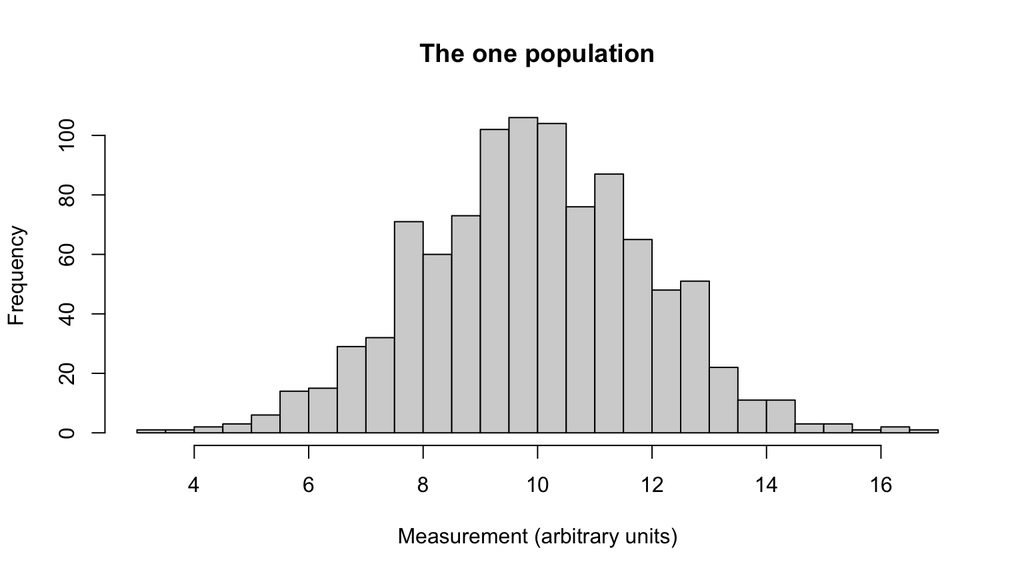

```r
set.seed(42)

d <- rnorm(n = 1000, mean = 10, sd = 2)   # one population, no groups in it
hist(d, breaks = 40, main = "The one population", xlab = "Measurement (arbitrary units)")
```

```r
p_values <- numeric(2000)
draws <- matrix(NA_integer_, nrow = 2000, ncol = 40)

for (i in 1:2000) {
  idx <- sample(1000, size = 40)          # 40 individuals
  draws[i, ] <- idx
  p_values[i] <- t.test(d[idx[1:20]], d[idx[21:40]])$p.value   # split 20 / 20
}

sum(p_values < 0.05)               # how many "significant" results from nothing
```

```
## [1] 106
```

```r
100 * sum(p_values < 0.05) / 2000  # as a percentage
```

```
## [1] 5.3
```

```r
min(p_values)                      # the most convincing result I never had
```

```
## [1] 0.0004705135
```

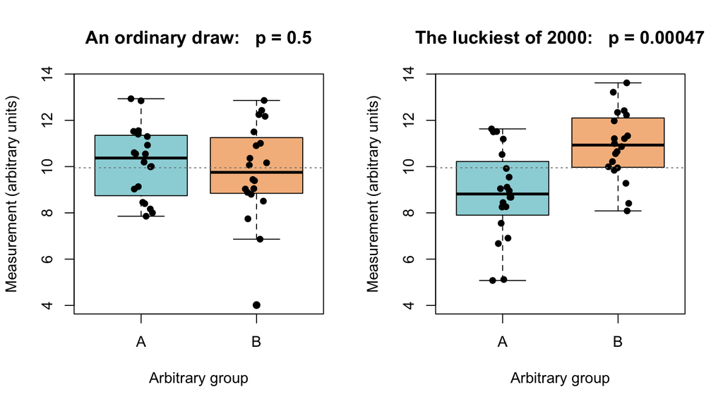

```r
# Pick out one ordinary draw and the single most extreme one
ordinary <- which.min(abs(p_values - 0.5))
extreme  <- which.min(p_values)

show_draw <- function(run, label) {
  g <- list(A = d[draws[run, 1:20]], B = d[draws[run, 21:40]])
  boxplot(g, ylim = range(d[draws[c(ordinary, extreme), ]]),
          col = c("#9bd5db", "#f4bb8b"),
          xlab = "Arbitrary group", ylab = "Measurement (arbitrary units)",
          main = paste0(label, "   p = ", signif(p_values[run], 2)))
  stripchart(g, vertical = TRUE, method = "jitter", add = TRUE, pch = 16)
  abline(h = mean(d), col = "grey50", lty = 3)   # the one true mean
}

set.seed(1)
par(mfrow = c(1, 2))
show_draw(ordinary, "An ordinary draw:")
show_draw(extreme,  "The luckiest of 2000:")
```

The dotted grey line is the truth: both groups were drawn from the same population, and that is its mean. Every point on both panels came out of the same jar.

The left panel is what “nothing is happening” usually looks like. Two boxes sitting on top of each other, p somewhere in the middle of its range, nobody writes a paper.

The right panel is the best of 2000 attempts. Look at it properly. The boxes barely overlap, the medians are clearly separated, and the p-value in the title would survive any threshold. If I had run this experiment once, on a Tuesday, and this is what came back, I would have believed it. I would have put that figure in a manuscript. There is nothing there. Both groups are twenty people picked at random out of the same thousand.

That is the whole point. A p-value is a statement about how often data like yours turn up when nothing is happening — and “not often” is not the same as “never”. Run the experiment enough times and the rare outcome arrives on schedule: roughly one draw in twenty below 0.05, printed above as a count out of 2000.

**Quiz:** Tomorrow you run one real experiment and get p = 0.0001. Which statement is honest?

- Chance has been ruled out: the difference is real
- Data like these are rare when nothing is happening, so I will act as though the effect is real - accepting that I might be just somebody’s lucky draw
- There is a 0.01% probability that I am wrong

**Discuss with your partner, then reveal**

Data like these are rare when nothing is happening, so I will act as though the effect is real - accepting that I might be just somebody’s lucky draw. The right-hand panel above had a p-value like that, and both groups came out of the same jar. No p-value can tell you whether this particular result is the real thing or the rare accident, because both produce the same number. What it tells you is how often you are willing to be fooled in the long run. That is a probability you accept, not a certainty you obtain.

**🔍 Deeper: why “p = 0.0001” is not “a 0.01% chance I am wrong”**

The p-value is computed **in a world where the null is true**. That assumption is the input. You cannot then read the answer back out as the probability that the assumption was wrong — the number is conditional on exactly the thing it is being asked to judge.

- What the p-value is: P(data at least this extreme **given** no effect)
- What people may wrongly say it is: P(no effect **given** this data)

Those are different quantities, and the gap between them depends on something the p-value has no access to: how plausible your hypotheses were before you tested them.

Count it out. Screen 1000 candidate compounds at the usual 0.05 threshold, with enough power to catch 80% of the real ones.

| Of 1000 screened | Really work | Come out significant | Wrong hits |
| --- | --- | --- | --- |
| 10% of them work | 100 | 80 real + 45 false = 125 | **36%** |
| 90% of them work | 900 | 720 real + 5 false = 725 | **0.7%** |

Same threshold, same p-values, same statistics. In the first screen more than a third of your hits are rubbish; in the second, almost none. The difference is entirely in what you chose to test.

## Mission 7 · Many questions, many chances

**Goal:** explain what a Bonferroni-adjusted p-value means and why the number of questions you asked matters.

### The ideas behind this mission

A p-value threshold of 0.05 means: when nothing is going on, one test in twenty will still come out “significant” by chance. That is the price of the method, and it is acceptable for one pre-planned question. The trouble starts when you ask many questions. With 20 independent tests and no real effects, the chance that *at least one* is significant is 1 − 0.95^20 ≈ 64%. With 100 tests it is over 99%. Screening every protein on a panel, every gene in an RNA-seq experiment or every variable in a patient table against the outcome guarantees “findings”, most of them noise. This is the **multiple testing problem**, and it is one of the main reasons published results fail to replicate.

The fix has two parts. First, be honest about the **family**: the set of tests that together support one claim. “At least one of these proteins differs” is a claim about the whole family, so the error rate has to be controlled for the whole family. Second, adjust. **Bonferroni** is the simplest correction: multiply each p-value by the number of tests (or, equivalently, compare each against 0.05 divided by that number). It keeps the chance of any false positive in the family at about 5%. It is deliberately strict and can hide real effects when the family is large; methods such as Holm or the **false discovery rate** (Benjamini–Hochberg, standard in omics) are less conservative, but the logic is the same: more questions, higher bar.

The deeper distinction is between **confirmatory** and **exploratory** analysis. A confirmatory test answers a question you wrote down before looking at the data; its p-value means what it says. An exploratory analysis looks around to generate ideas; its p-values are hints, not evidence, and the honest report says so. Both are legitimate science. What is not legitimate is exploring twenty variables, reporting the one that “worked” as if it had been the plan, and letting the reader believe a single test was run.

### The jelly bean problem

xkcd 882, “Significant”: twenty colours of jelly beans tested for a link to acne; only green comes out significant.

If nothing at all is going on and you test twenty hypotheses at the 0.05 level, you still expect about one “significant” result by pure chance. (The classic cartoon: scientists test twenty colours of jelly beans for acne; green comes out at p < 0.05 and makes the newspaper.) Every extra test is another lottery ticket.

Tests that are asked together to support one claim form a **family**. Before looking at results, write down how many tests are in the family. The **Bonferroni** correction then multiplies each p-value by the family size *m* (and caps it at 1): adjusted p = min(m × p, 1). This keeps the chance of *any* false positive in the family at about 0.05. It is simple and a bit conservative. It changes the threshold for calling something significant. It changes neither the data nor the estimated effects.

### A worked family of three

Three invented p-values for three proteins tested in the same experiment. Run the code. Then add two new lines: one that extends `raw_p` with a fourth protein, `protein_D = 0.04`, and one that prints the table again. **Submit Answer**. What happens to all four adjusted values?

```
raw_p <- c(protein_A = 0.01, protein_B = 0.03, protein_C = 0.20)
data.frame(raw_p, adjusted_p = p.adjust(raw_p, method = "bonferroni"))
```

```
# c() can extend an existing vector:  raw_p <- c(raw_p, protein_D = 0.04)
# Then repeat the data.frame( ... ) line.
```

```
# Every adjusted value is min(m * p, 1). With four tests, m becomes 4 for all of them.
```

```
raw_p <- c(protein_A = 0.01, protein_B = 0.03, protein_C = 0.20)
data.frame(raw_p, adjusted_p = p.adjust(raw_p, method = "bonferroni"))
raw_p <- c(raw_p, protein_D = 0.04)
data.frame(raw_p, adjusted_p = p.adjust(raw_p, method = "bonferroni"))
```

These numbers are an arithmetic illustration, not results from the MMSE data.

**Quiz:** Which tests belong to the family in this example?

- All three protein tests, because together they support the claim ‘at least one protein differs’
- Only the test with the smallest p-value
- The three protein tests plus the Shapiro-Wilk normality checks

**Discuss with your partner, then reveal**

All three protein tests, because together they support the claim ‘at least one protein differs’. A family is the set of tests that jointly support one claim. Assumption checks are not part of it; they are not scientific claims.

**Quiz:** For the original three tests, which results remain below 0.05 after Bonferroni adjustment?

- Protein A only (0.01 becomes 0.03)
- Proteins A and B
- None of them

**Discuss with your partner, then reveal**

Protein A only (0.01 becomes 0.03). Protein B goes from 0.03 to 0.09. That does not establish ‘no effect’; it means the evidence is weaker than it first looked once we admit we asked three questions.

**Quiz:** A report mentions only protein A with p = 0.01 and says nothing about B and C. Why is that incomplete?

- Because p = 0.01 is not small enough
- Because the reader cannot judge how many questions were asked; with many tests, small p-values appear by chance
- Because protein A should have been tested twice

**Discuss with your partner, then reveal**

Because the reader cannot judge how many questions were asked; with many tests, small p-values appear by chance. Show every test in the family, including the non-significant ones. Hiding them is selective reporting, and no correction can repair it afterwards.

**Quiz:** Raw p = 0.03 became 0.09 after adjustment. What changed?

- The measured effect became three times smaller
- Only the p-value; the data and the estimated effect are exactly the same
- There is now a 9% chance that the null hypothesis is true

**Discuss with your partner, then reveal**

Only the p-value; the data and the estimated effect are exactly the same. Adjustment changes the decision threshold, not the biology. Report the estimate and its CI regardless of the adjusted p.

**Number check:** By hand: a family of 5 tests, one raw p = 0.02. What is its Bonferroni-adjusted p?

**Discuss with your partner, then reveal**

0.1. 5 x 0.02 = 0.10. Below 1, so no capping. It is no longer below 0.05.

**Quiz:** An LLM helpfully suggests testing every one of the nine variables in tomorrow’s dataset against the dementia group. What is the catch?

- None; more tests mean more discoveries
- That is a family of nine tests, so chance findings become likely; decide the questions first and adjust or disclose
- LLMs are not allowed to suggest tests

**Discuss with your partner, then reveal**

That is a family of nine tests, so chance findings become likely; decide the questions first and adjust or disclose. Searching many variables and reporting the winners is the jelly bean problem. Pre-specify, report everything, and adjust when several tests support one claim.

**Your explanation:** Tomorrow you will run one group comparison and one correlation. Do they form a family? What will you report, and what would change if you also tried five extra variables ‘just to see’?

**Discuss with your partner, then reveal**

Two planned analyses answering two different questions can be reported as two separate results with both p-values shown; if you claim ‘we found an effect in at least one of them’, that is a family of two and Bonferroni doubles each p. Five extra exploratory tests must be disclosed as exploratory, adjusted for, or not claimed as findings.

## Mission 8 · Association detective

**Goal:** read one scatterplot, choose a correlation target, and avoid causal overstatement.

### The ideas behind this mission

So far each person contributed one number and a group label. Often each unit contributes **two measurements**, and the question is whether they move together: does brain volume decrease with age, does a biomarker rise with disease severity, does assay A predict assay B? This is an **association**, and the first tool is not a test but a **scatterplot**, one point per unit. Look for direction (up or down), form (a straight line, a curve, a threshold), clusters (two groups hiding in one cloud) and single points far from the rest, which can create or destroy an apparent relationship on their own.

A **correlation coefficient** compresses the plot into one number between −1 and +1. **Pearson’s r** measures how close the points lie to a straight line: +1 is a perfect rising line, −1 a perfect falling line, 0 no *linear* trend. **Spearman’s rho** does the same with ranks, so it captures any consistently rising or falling relationship, straight or curved, and is less disturbed by extreme values. Neither says anything about the slope (how much B changes per unit of A), and a value of 0 does not mean “no relationship”: a U-shaped relationship has r near zero. The coefficient comes with its own p-value and confidence interval, because a sample of 30 units estimates the population correlation with uncertainty, exactly as a sample mean estimates a population mean.

The sentence every biologist has heard, and still needs, is **correlation is not causation**. Two variables can move together because one drives the other, because a third variable drives both (a **confounder**: older patients have both more disease and smaller brains), because the units were selected in a particular way, or by chance. Observational data can show an association and suggest a hypothesis; only an experiment in which you control the cause, or careful design and adjustment, can support a causal claim. Write “was associated with”, and reserve “caused” or “led to” for what the design can actually show.

### Two measurements per unit

A **scatterplot** shows one point per unit with two measurements. Look for direction (up or down), form (line or curve), clusters and influential points. **Pearson’s r** measures linear association; **Spearman’s rho** measures monotonic association using ranks. Both run from −1 to 1; 0 means no linear (or monotonic) association, not “no relationship at all”.

The data here are a seeded simulation of 30 independent values with two arbitrary assay signals. Predict the direction, run, then add a new `cor.test()` line with `method = "spearman"` and **Submit Answer**.

```
plot(assay$signal_a, assay$signal_b, pch = 16,
     xlab = "Assay A (arbitrary units)", ylab = "Assay B (arbitrary units)")
cor.test(assay$signal_a, assay$signal_b, method = "pearson")
```

```
# Read the "cor" estimate, not only the p-value. Pearson: how linear is it?
# Spearman: does B tend to increase whenever A increases? Add exact = FALSE for ties.
```

```
plot(assay$signal_a, assay$signal_b, pch = 16,
     xlab = "Assay A (arbitrary units)", ylab = "Assay B (arbitrary units)")
cor.test(assay$signal_a, assay$signal_b, method = "pearson")
cor.test(assay$signal_a, assay$signal_b, method = "spearman", exact = FALSE)
```

**Quiz:** Pearson r = 0.75 with p < 0.001. What does r = 0.75 tell you that p does not?

- How strong and in which direction the linear association is
- That A causes B
- That the sample is large

**Discuss with your partner, then reveal**

How strong and in which direction the linear association is. p answers ‘is there evidence of any association?’; r answers ‘how strong?’. Always report the coefficient, the sample size and the plot.

**Quiz:** Tomorrow you will see an overall age–MMSE association in observational data. The dementia group is also older. What next?

- Conclude that age causes the lower scores
- Colour the scatterplot by group and think about confounding and study design
- Use whichever correlation method gives the smaller p-value

**Discuss with your partner, then reveal**

Colour the scatterplot by group and think about confounding and study design. Pooling groups can create or hide associations (Simpson’s paradox). Correlation never establishes causation on its own.

**Your explanation:** Describe the direction and form of the scatterplot, report the coefficient, and give one limitation. What would you check before correlating patient measurements tomorrow?

**Discuss with your partner, then reveal**

Positive, roughly linear, r about 0.75 (n = 30). Check that each point is one independent participant, that both values belong to the same participant, how missing pairs are handled, and whether groups form separate clusters.

## Finish · What you can do now

Close the tutorial for a moment and rebuild today’s workflow with your partner, from memory: **question → what one row is → plot → assumptions → method → estimate with uncertainty → limitation**. Then check it against the decision worksheet in Mission 5 and the command card in the last section.

Your scientific story is your own, even when you shared code with a partner. Tomorrow each of you writes your own explanation of an analysis.

**Your explanation:** What can you now do in R? Which decision still needs help? What did you not understand?

**Discuss with your partner, then reveal**

### Download my work

Everything you ran and answered today can be saved as one HTML file: every code window with your last version of the code, every quiz with your answer, every reflection you recorded. Type your name, click the button, and keep the file.

### Tomorrow

Day 2 is an investigation with real dementia data (OASIS): **one group comparison and one association**, with your question and method recorded *before* you look at p-values. You will check whether rows are people or visits, handle missing values, and write the story in an R Markdown notebook that you knit to HTML. Keep the decision worksheet, the Bonferroni example and the command card beside you.

## Toolbox A · Vectors and vectorised maths

*Optional reference. Use it during Day 2 or when your pair is ahead.*

### Kinds of vectors

A vector is an ordered set of values of the same type. Run this and read what `class()` reports for each.

```
lengths_um <- c(12.3, 15.8, 9.4, 18.1)     # numeric
conditions <- c("control", "condition_1", "condition_2")   # character (text)
keepers <- c(TRUE, FALSE, TRUE, TRUE)      # logical
length(lengths_um)
class(lengths_um)
class(conditions)
class(keepers)
```

```
lengths_um <- c(12.3, 15.8, 9.4, 18.1)
conditions <- c("control", "condition_1", "condition_2")
keepers <- c(TRUE, FALSE, TRUE, TRUE)
length(lengths_um)
class(lengths_um)
class(conditions)
class(keepers)
```

### One operation, every element

R applies arithmetic to every element at once (**vectorisation**), so you rarely need loops. Run these.

```
lengths_um <- c(12.3, 15.8, 9.4, 18.1)
lengths_um + 3
lengths_um * 5
lengths_um^2
noise <- c(0.5, -0.2, 0.0, 1.1)
lengths_um + noise        # element by element
log10(lengths_um)
round(lengths_um, digits = 0)
cumsum(lengths_um)        # running sum
lengths_um > 12           # a logical vector
which(lengths_um > 12)    # positions where it is TRUE
```

```
lengths_um <- c(12.3, 15.8, 9.4, 18.1)
lengths_um + 3
which(lengths_um > 12)
```

**🔍 Deeper: the recycling rule**

If two vectors have different lengths, R **recycles** the shorter one. `c(1, 2, 3, 4) + c(-1, 1)` gives `0 3 2 5`. If the lengths are not multiples of each other R still recycles but warns. Treat that warning as a bug in your code.

### Exercises

1. Increase every value of `lengths_um` by 10% (expected growth). Submit when the last line prints the new vector.

```
lengths_um <- c(12.3, 15.8, 9.4, 18.1)
```

```
# Ten percent more means multiplying by 1.1
```

```
lengths_um <- c(12.3, 15.8, 9.4, 18.1)
lengths_um * 1.1
```

2. Apply a microscope calibration: multiply each value by 0.98 and subtract a blank offset of 0.15 µm. Store the result as `calibrated` and print it.

```
lengths_um <- c(12.3, 15.8, 9.4, 18.1)
```

```
# calibrated <- lengths_um * 0.98 - 0.15
```

```
lengths_um <- c(12.3, 15.8, 9.4, 18.1)
calibrated <- lengths_um * 0.98 - 0.15
calibrated
```

3. Which positions of `calibrated` are above 15 µm, and what are those values?

```
lengths_um <- c(12.3, 15.8, 9.4, 18.1)
calibrated <- lengths_um * 0.98 - 0.15
```

```
# which(calibrated > 15) gives positions; calibrated[calibrated > 15] gives values.
```

```
lengths_um <- c(12.3, 15.8, 9.4, 18.1)
calibrated <- lengths_um * 0.98 - 0.15
which(calibrated > 15)
calibrated[calibrated > 15]
```

4. Compute the z-scores of `lengths_um` (done in Mission 3 for MMSE; repeat it here from memory).

```
lengths_um <- c(12.3, 15.8, 9.4, 18.1)
```

```
lengths_um <- c(12.3, 15.8, 9.4, 18.1)
(lengths_um - mean(lengths_um)) / sd(lengths_um)
```

## Toolbox B · Data frames and slicing

*Optional reference, using the neurite outgrowth data.*

### The neurite story

Neurites are the projections that grow out of a neuron’s cell body. In the old course scenario, neurite outgrowth was measured in cell cultures after two differentiation treatments and in untreated controls, and exported to a CSV with three columns: `control`, `condition_1`, `condition_2` (20 values each). The data are synthetic; units are not documented. Rows are **not** matched: row 1 of `control` and row 1 of `condition_1` are different cultures.

### Build a tiny data frame by hand

```
df_demo <- data.frame(
  control     = c(0.45, 0.62, 0.51),
  condition_1 = c(0.60, 0.70, 0.66),
  condition_2 = c(0.80, 0.77, 0.83)
)
df_demo
class(df_demo)
nrow(df_demo); ncol(df_demo); dim(df_demo)
str(df_demo)
```

```
df_demo <- data.frame(
  control     = c(0.45, 0.62, 0.51),
  condition_1 = c(0.60, 0.70, 0.66),
  condition_2 = c(0.80, 0.77, 0.83)
)
str(df_demo)
```

### Import and inspect the neurite file

```
neurites <- read.csv("data/neurites.csv")
head(neurites)
dim(neurites)
colnames(neurites)
str(neurites)
summary(neurites)
```

```
neurites <- read.csv("data/neurites.csv")
summary(neurites)
```

The `neurites` data frame is preloaded in every window below.

### Three ways to pick columns, one way to pick rows

`$` by name; `[ , "name"]` by name inside square brackets; `[ , 1]` by position. The comma separates **rows** (before) from **columns** (after); leaving one side empty means “all”.

```
neurites$control
neurites[ , "condition_1"]
neurites[ , 1:2]
neurites[ , c("control", "condition_2")]
neurites[1:5, ]                  # first five rows, all columns
neurites[1:2, c("control", "condition_2")]
```

```
neurites[1:2, c("control", "condition_2")]
```

### Logical filters

A comparison gives a logical vector; using it as the row index keeps the rows where it is `TRUE`. `&` means AND, `|` means OR.

```
neurites$control > 0.5
neurites[neurites$control > 0.5, ]
neurites[neurites$condition_1 > neurites$control & neurites$condition_2 > neurites$control, ]
```

```
neurites[neurites$control > 0.5, ]
```

**Exercise:** print the rows where `control` is greater than 0.2 **and** `condition_1` is greater than 1.

```
# neurites[ CONDITION_A & CONDITION_B , ]
```

```
neurites[neurites$control > 0.2 & neurites$condition_1 > 1, ]
```

### Add a new column

```
neurites$delta_1 <- neurites$condition_1 - neurites$control
head(neurites)
```

```
neurites$delta_1 <- neurites$condition_1 - neurites$control
head(neurites)
```

### Independent exercises

Use `neurites`. Each window checks the last line.

1. For each column, compute mean and SD in one go. (`sapply(neurites, mean)` applies a function to every column.)

```
sapply(neurites, mean)
```

```
# Change mean to sd for the second line.
```

```
sapply(neurites, mean)
sapply(neurites, sd)
```

2. Compute mean, SD, median and quartiles of `condition_2` (the “same statistics for the other columns” exercise).

```
mean(neurites$condition_2)
```

```
mean(neurites$condition_2)
sd(neurites$condition_2)
median(neurites$condition_2)
quantile(neurites$condition_2, probs = c(0.25, 0.5, 0.75))
```

3. **Challenge:** create a logical column `is_best2` that is `TRUE` when `condition_2` is greater than both `control` and `condition_1`. Then count with `table()`.

```
neurites$is_best2 <- ___
table(neurites$is_best2)
```

```
# neurites$condition_2 > neurites$control & neurites$condition_2 > neurites$condition_1
```

```
neurites$is_best2 <- neurites$condition_2 > neurites$control &
  neurites$condition_2 > neurites$condition_1
table(neurites$is_best2)
```

**Quiz:** What does neurites[neurites$control > 0.5, ] return?

- The control column only
- All columns, but only the rows where control exceeds 0.5
- An error, because nothing follows the comma

**Discuss with your partner, then reveal**

All columns, but only the rows where control exceeds 0.5. Rows before the comma, columns after. Empty after the comma means every column.

**🔍 Deeper: wide versus long tables**

`neurites` is **wide**: one column per group. Many R functions (and `ggplot2`) prefer **long** format: one row per observation with a `values` column and a group column. Base R converts with `stack(neurites)`; the `reshape2` and `tidyr` packages offer `melt()` and `pivot_longer()` for the same job. Notice that our MMSE table was already long. Long format is the natural shape when every row is one observation.

```r
long_neurites <- stack(neurites)     # columns: values, ind
head(long_neurites)
```

## Gallery · More plots, base R and ggplot2

*Optional reference. Interpretation first, decoration second.*

### Barplot of group means, step by step

```
mean_control <- mean(neurites$control)
mean_cond1 <- mean(neurites$condition_1)
mean_cond2 <- mean(neurites$condition_2)
barplot(c(mean_control, mean_cond1, mean_cond2))          # bare bones
barplot(c(mean_control, mean_cond1, mean_cond2),          # labelled, coloured
        names.arg = c("Control", "Condition 1", "Condition 2"),
        col = c("lightblue", "lightgreen", "lightcoral"),
        main = "Mean neurite outgrowth by condition",
        ylab = "Mean measurement (synthetic units)")
```

```
barplot(sapply(neurites, mean),
        names.arg = c("Control", "Condition 1", "Condition 2"),
        col = c("lightblue", "lightgreen", "lightcoral"),
        ylab = "Mean measurement (synthetic units)")
```

Remember Mission 4: a bar hides the points. The boxplot of a whole data frame draws one box per column.

```
boxplot(neurites,
        main = "Neurite outgrowth by condition",
        ylab = "Measurement (synthetic units)",
        col = c("lightblue", "lightgreen", "lightcoral"),
        names = c("Control", "Condition 1", "Condition 2"))
set.seed(1)
stripchart(neurites, vertical = TRUE, method = "jitter", add = TRUE, pch = 16)
```

```
boxplot(neurites[c("control", "condition_1")], col = c("lightblue", "lightgreen"))
```

### Histograms with a density curve

```
hist(neurites$control, breaks = 10, xlab = "Control measurement", main = "Distribution of control")
lines(density(neurites$control))
```

```
# Repeat for condition_1 and condition_2. Try breaks = 5 and breaks = 20.
```

```
par(mfrow = c(1, 3))
hist(neurites$control, breaks = 10, main = "control", xlab = "")
hist(neurites$condition_1, breaks = 10, main = "condition_1", xlab = "")
hist(neurites$condition_2, breaks = 10, main = "condition_2", xlab = "")
```

### Saving a figure as a PDF

In an R Markdown document the figures are embedded automatically. For a standalone figure, open a PDF “device”, draw, and close it. A forgotten `dev.off()` leaves the device open and later plots vanish into the file.

```
pdf(file = "neurites_plot.pdf", width = 6, height = 4)
boxplot(neurites, col = c("lightblue", "lightgreen", "lightcoral"))
dev.off()
list.files(pattern = "pdf")     # the file now exists in the working directory
```

```
pdf(file = "neurites_plot.pdf", width = 6, height = 4)
boxplot(neurites, col = c("lightblue", "lightgreen", "lightcoral"))
dev.off()
```

### The same plots in ggplot2

`ggplot2` builds a plot from layers and wants **long** data. `aes()` maps columns to axes and colours; `geom_*()` layers add bars, points, boxes; `+` stacks layers.

```
library(ggplot2)
head(long_neurites)
ggplot(long_neurites, aes(x = condition, y = value)) +
  stat_summary(fun = mean, geom = "bar", fill = "lightblue", colour = "black")
```

```
library(ggplot2)
ggplot(long_neurites, aes(x = condition, y = value, fill = condition)) +
  stat_summary(fun = mean, geom = "bar", colour = "black") +
  theme_classic()
```

```
library(ggplot2)
ggplot(long_neurites, aes(x = value)) + geom_histogram(bins = 15)            # pooled
ggplot(long_neurites, aes(x = value, fill = condition)) +
  geom_histogram(bins = 15, colour = "black") +
  facet_wrap(~ condition) + theme_classic()                                  # one panel per group
```

```
library(ggplot2)
ggplot(long_neurites, aes(x = value, fill = condition)) +
  geom_histogram(bins = 15, colour = "black") + facet_wrap(~ condition) + theme_classic()
```

```
library(ggplot2)
ggplot(long_neurites, aes(x = condition, y = value, fill = condition)) +
  geom_boxplot() +
  geom_jitter(width = 0.2, height = 0) +
  labs(x = "Condition", y = "Neurite measurement (synthetic units)") +
  theme_bw()
```

```
# Replace geom_boxplot() with geom_violin() and keep the jittered points.
# Delete the boxplot layer to get a pure jitter (strip) plot.
```

```
library(ggplot2)
ggplot(long_neurites, aes(x = condition, y = value, fill = condition)) +
  geom_violin() +
  geom_jitter(width = 0.15, height = 0) +
  labs(x = "Condition", y = "Neurite measurement (synthetic units)") +
  theme_bw()
```

**🔍 Deeper: ridge plots and ggsave**

Another option is the **density ridge plot** from the `ggridges` package (one smoothed density per group, stacked like a mountain range):

```r
install.packages("ggridges")
library(ggridges)
ggplot(long_neurites, aes(x = value, y = condition, fill = condition)) +
  geom_density_ridges() + theme_bw()
```

`ggsave("my_plot.pdf")` saves the most recent ggplot to a file.

**Quiz:** A reviewer asks you to show the variability in each group and the sample size. Which figure is the weakest choice?

- Boxplot with jittered points
- Bar chart of means without error bars or points
- Violin plot with points

**Discuss with your partner, then reveal**

Bar chart of means without error bars or points. Bars hide everything except one number per group.

## Extras · More tests, for later

*Optional material. Not required today.*

### Student versus Welch, and the F-test

The classic Student t-test assumes equal variances in both groups (`var.equal = TRUE`). An older recipe first runs an **F-test** (`var.test()`) to compare the two variances and then chooses. Modern practice skips that gate: Welch is safe either way, and the F-test itself is fragile with skewed data. Run all three and compare the p-values and degrees of freedom.

```
var.test(neurites$control, neurites$condition_1)
t.test(neurites$control, neurites$condition_1, var.equal = TRUE)    # Student
t.test(neurites$control, neurites$condition_1)                      # Welch (default)
```

```
var.test(neurites$control, neurites$condition_1)
t.test(neurites$control, neurites$condition_1, var.equal = TRUE)
t.test(neurites$control, neurites$condition_1)
```

**Exercise:** run the t-test for `condition_2` versus `control` and store it as `test_2vsC`. Print its p-value alone with `$p.value`.

```
# test_2vsC <- t.test(neurites$condition_2, neurites$control)
# test_2vsC$p.value
```

```
test_2vsC <- t.test(neurites$condition_2, neurites$control)
test_2vsC$p.value
```

### Fold change and log2 fold change

Biologists often report a **ratio** of group means (fold change), especially for expression data. A ratio only makes sense when zero means “nothing” (a ratio scale). Neurite outgrowth qualifies; an MMSE score does not.

```
mean(neurites$condition_1) - mean(neurites$control)   # difference
mean(neurites$condition_1) / mean(neurites$control)   # fold change
log2(mean(neurites$condition_1) / mean(neurites$control))
```

```
# Repeat for condition_2. Which treatment has the larger effect? Which has more variability?
```

```
fc1 <- mean(neurites$condition_1) / mean(neurites$control)
fc2 <- mean(neurites$condition_2) / mean(neurites$control)
c(fold_change_1 = fc1, fold_change_2 = fc2)
log2(c(fc1, fc2))
sapply(neurites, sd)
```

**Quiz:** Condition 2 has a larger fold change than condition 1 but also a much larger SD. What does that tell you?

- Condition 2 is simply better
- The average effect is larger, but individual cultures respond very differently; both the estimate and its uncertainty matter
- The data for condition 2 must be wrong

**Discuss with your partner, then reveal**

The average effect is larger, but individual cultures respond very differently; both the estimate and its uncertainty matter. Look at the CI of each comparison: a large variable effect can be less certain than a smaller consistent one.

### More than two groups

A one-way **ANOVA** asks whether all group means are equal; it does not say which groups differ. **Kruskal–Wallis** is its rank-based cousin. Follow-up pairwise comparisons form a family and need multiplicity control.

```
long_neurites <- stack(neurites)
oneway.test(values ~ ind, data = long_neurites, var.equal = FALSE)   # Welch ANOVA
kruskal.test(values ~ ind, data = long_neurites)
```

```
long_neurites <- stack(neurites)
oneway.test(values ~ ind, data = long_neurites, var.equal = FALSE)
kruskal.test(values ~ ind, data = long_neurites)
```

```
raw_p <- c(
  c1_vs_control = t.test(neurites$condition_1, neurites$control)$p.value,
  c2_vs_control = t.test(neurites$condition_2, neurites$control)$p.value,
  c2_vs_c1      = t.test(neurites$condition_2, neurites$condition_1)$p.value
)
data.frame(raw_p, bonferroni = p.adjust(raw_p, method = "bonferroni"))
```

```
raw_p <- c(
  c1_vs_control = t.test(neurites$condition_1, neurites$control)$p.value,
  c2_vs_control = t.test(neurites$condition_2, neurites$control)$p.value,
  c2_vs_c1      = t.test(neurites$condition_2, neurites$condition_1)$p.value
)
data.frame(raw_p, bonferroni = p.adjust(raw_p, method = "bonferroni"))
```

### Categorical data: the chi-square test

When both variables are categories, we compare **counts**. This invented 2×2 table records whether an assay detected a marker in two independent groups. Inspect the expected counts: if any is below 5, use Fisher’s exact test.

```
counts <- matrix(c(18, 12, 9, 21), nrow = 2, byrow = TRUE,
                 dimnames = list(group = c("Control", "Treatment"),
                                 marker = c("Detected", "Not detected")))
counts
chisq.test(counts)
chisq.test(counts)$expected
```

```
# fisher.test(counts) gives an exact p-value for small tables.
# With real data you build the table with table(data$var1, data$var2).
```

```
counts <- matrix(c(18, 12, 9, 21), nrow = 2, byrow = TRUE,
                 dimnames = list(group = c("Control", "Treatment"),
                                 marker = c("Detected", "Not detected")))
chisq.test(counts)
fisher.test(counts)
```

**Quiz:** Which question calls for a chi-square test?

- Is the mean MMSE different between groups?
- Is dementia status associated with sex in this sample?
- Is age correlated with brain volume?

**Discuss with your partner, then reveal**

Is dementia status associated with sex in this sample?. Chi-square compares observed counts in categories with the counts expected if the two variables were independent.

### Paired observations

The same eight units measured before and after treatment. Pairing comes from the design, never from two vectors happening to have the same length. A paired t-test analyses the within-unit **changes**.

```
before <- c(10, 12, 8, 14, 11, 9, 13, 10)
after  <- c(11, 14, 8, 17, 12, 11, 14, 12)
change <- after - before
change
t.test(after, before, paired = TRUE)
```

```
before <- c(10, 12, 8, 14, 11, 9, 13, 10)
after  <- c(11, 14, 8, 17, 12, 11, 14, 12)
change <- after - before
qqnorm(change); qqline(change)
t.test(after, before, paired = TRUE)
```

**Quiz:** Eight participants are measured before and after treatment. Which statement is right?

- Treat the 16 measurements as 16 separate people
- Use the pairing: analyse the eight within-person changes
- Pairing can be assumed whenever two columns have equal length

**Discuss with your partner, then reveal**

Use the pairing: analyse the eight within-person changes. Pairing removes between-person variability and answers ‘did individuals change?’. The design and the IDs establish it.

## Command card and references

### Command card

Everything you need for today’s questions. `d`, `x`, `y` and `g` are placeholders for your own objects. Entries marked **(new)** did not appear on the Day 1 card.

| Need | Pattern |
| --- | --- |
| Store values | `x <- c(27, 28, 30)` |
| Import | `d <- read.csv("data/alzheimer_data.csv", header = TRUE)` |
| First look | `head(d)`; `dim(d)`; `nrow(d)`; `ncol(d)`; `names(d)`; `str(d)`; `summary(d)` |
| What type is a column? | `class(d$Age)`; `str(d)` |
| Distinct values of a column | `unique(d$CDR)` **(new)** |
| One column / one group | `d$MMSE`; `d$MMSE[d$Group == "Demented"]` |
| Rows and columns | `d[rows, cols]`; `d[d$MMSE < 20, ]`; `d[d$Group == "Demented" & d$sex == "M", ]` |
| Counts | `table(d$Group)`; `table(d$sex, d$Group)` |
| Missing values | `sum(is.na(d$SES))`; `colSums(is.na(d))` **(new)**; `mean(x, na.rm = TRUE)`; `x[!is.na(x)]` |
| Add a column | `d$is_senior <- d$Age > 80` |
| Summaries | `mean(x)`; `median(x)`; `sd(x)`; `min(x)`; `max(x)`; `range(x)` **(new)**; `quantile(x)`; `IQR(x)` |
| Round a number | `round(x, digits = 2)` **(new)** |
| Summaries per group | `tapply(d$Age, d$Group, mean)`; `tapply(d$Age, d$Group, sd)` |
| Every column at once | `sapply(d, class)`; `sapply(d, mean)` |
| The row with the highest / lowest value | `d[which.min(d$MMSE), ]`; `d[which.max(d$MMSE), ]` **(new)** |
| Distribution plots | `hist(x)`; `boxplot(y ~ g, data = d)`; `stripchart(y ~ g, data = d, vertical = TRUE, method = "jitter", add = TRUE, pch = 16)` |
| Bar chart of group means | `barplot(tapply(d$MMSE, d$Group, mean))` **(new)** |
| Scatterplot | `plot(d$nWBV, d$MMSE, pch = 16)` |
| Colour points by group | `col = c("red", "blue")[factor(d$Group)]` **(new)** |
| Add a legend | `legend("topright", legend = levels(factor(d$Group)), col = c("red", "blue"), pch = 16)` **(new)** |
| Several plots in one window | `par(mfrow = c(2, 2))` **(new)** |
| Normality evidence | `qqnorm(x); qqline(x)`; `shapiro.test(x)` |
| Two groups, two vectors | `t.test(x, y)`; `wilcox.test(x, y, exact = FALSE)` |
| Two groups, one column + one grouping column | `t.test(MMSE ~ Group, data = d)`; `wilcox.test(MMSE ~ Group, data = d)` **(new)** |
| Paired | `t.test(after, before, paired = TRUE)` |
| More than two groups | `oneway.test(y ~ g, data = d)`; `kruskal.test(y ~ g, data = d)` |
| Association | `cor.test(x, y, method = "pearson")`; `cor.test(x, y, method = "spearman", exact = FALSE)` |
| Categories | `table(a, b)`; `chisq.test(counts)`; `chisq.test(counts)$expected`; `fisher.test(counts)` |
| Pull one number out of a test | `t.test(x, y)$p.value`; `$conf.int`; `$estimate` |
| Multiple testing | `p.adjust(p_values, method = "bonferroni")` |
| ggplot version | `ggplot(d, aes(nWBV, MMSE, colour = Group)) + geom_point()` |

### The result sentence

“In this sample (n = … per group), the estimated … minus … difference in mean … was … units (95% CI … to …, Welch’s t-test, p = …). The plots show …. This supports … under the assumption that …; it does not show ….”

### References

- R documentation: [t.test](https://stat.ethz.ch/R-manual/R-devel/library/stats/html/t.test.html), [wilcox.test](https://stat.ethz.ch/R-manual/R-devel/library/stats/html/wilcox.test.html), [cor.test](https://stat.ethz.ch/R-manual/R-devel/library/stats/html/cor.test.html), [boxplot](https://stat.ethz.ch/R-manual/R-devel/library/graphics/html/boxplot.html), [shapiro.test](https://stat.ethz.ch/R-manual/R-devel/library/stats/html/shapiro.test.html), [chisq.test](https://stat.ethz.ch/R-manual/R-devel/library/stats/html/chisq.test.html).
- The [ASA statement on p-values](https://magazine.amstat.org/blog/2016/03/07/pvalue-mar16/).
- [Hands-On Programming with R: installing R and RStudio](https://rstudio-education.github.io/hopr/starting.html).
- Q–Q plots and normality tests explained: [STHDA](http://www.sthda.com/english/wiki/normality-test-in-r).
- Data provenance: `data/README.md` in this project.